# Estudio variabilidad estructural proteica

30/01/2016

## Conjuntos de proteinas

### Conjunto teorico

280 mutantes de 1bxv (91 sitios) simuladas con el modelo mutacional LFENM con ANM *R0* = 12 y *Fmax* = 2 (solo para LFENM). Para determinar que sitios mutar, se alineo 1bxv con cada una de las proteinas del conjunto, se obtuvieron los indices de los sitios alineados pero mutados y se simularon 10 mutantes por cada par de proteinas, obteniendose un total de 280 mutantes. Luego, para el analisis, se tomaron como alineados los sitios alineados de 1bxv para cada par de proteinas.

### Conjunto experimental

28 proteinas de la familia de plastocyanins. Las proteinas tienen un promedio de identidad secuencial de 36%. El core del alineamiento de la familia es de 72 sitios.

La caracterizacion del conjunto experimental se muestra a continuacion:

```
##    pdbid nsites naligned identity        MSD
## 1  1rkra    129       86 24.41860 11.9796704
## 2  1jzga    128       86 23.25581 12.3859836
## 3  1nwpa    128       86 22.09302 12.6042129
## 4  1dz0a    129       86 18.60465 11.6946759
## 5  2azaa    129       86 19.76744 11.8338297
## 6   1kdj    102       89 33.70787  3.2032153
## 7  1m9wa     98       91 60.43956  1.1286724
## 8   1nin    105       91 54.94505  2.9015748
## 9  1bawa    105       91 61.53846  0.9056289
## 10 2b3ia     97       90 51.11111  1.6680600
## 11  1plb     97       89 41.57303  1.1538455
## 12  1ag6     99       89 44.94382  0.8913939
## 13  1plc     99       89 44.94382  0.6518551
## 14 1byoa     99       89 41.57303  0.7599670
## 15  1paz    120       83 30.12048 11.9233583
## 16  1bqk    124       83 32.53012 12.0886771
## 17 1adwa    123       83 32.53012 11.0093779
## 18 1id2a    106       80 32.50000  5.3975361
## 19 2raca    105       80 32.50000  4.4600694
## 20 1gy1a    154       86 27.90698  7.6945196
## 21  1joi    128       86 24.41860 12.9020099
## 22 1cuoa    129       86 22.09302 12.1710928
## 23  9pcy     99       89 40.44944  0.9206047
## 24  7pcy     98       90 41.11111  0.6301229
## 25  1iuz     98       90 45.55556  0.5677619
## 26  2plt     98       90 48.88889  0.4062136
## 27  1pmy    123       83 30.12048 11.6217421
## 28 1qhqa    139       88 31.81818 11.3517143
```

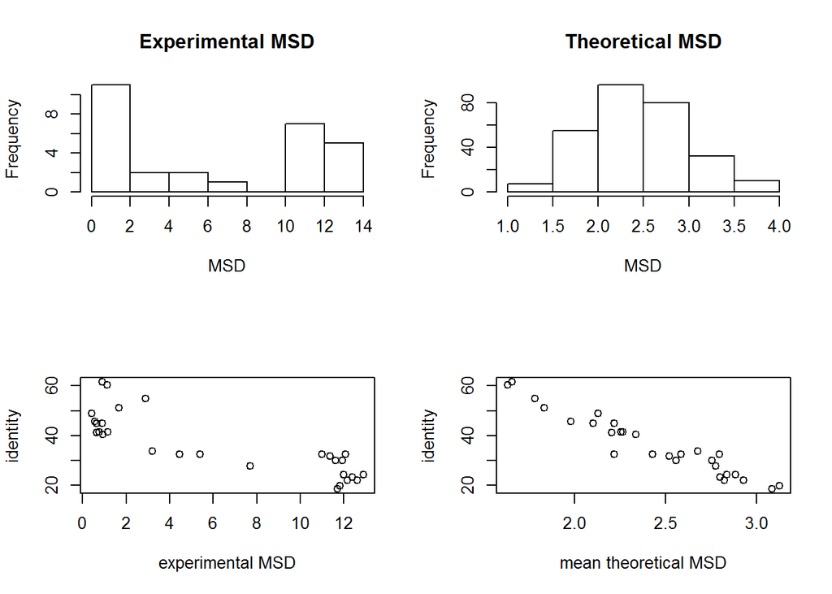

## Comparaciones

### RHO y AUC

Las distribuciones de *auc* y *rho* para cada conjunto se muestran a continuacion (azul= teorico, rojo = experimental)

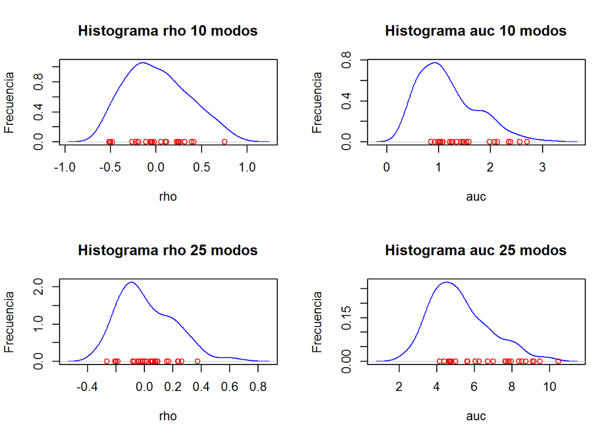

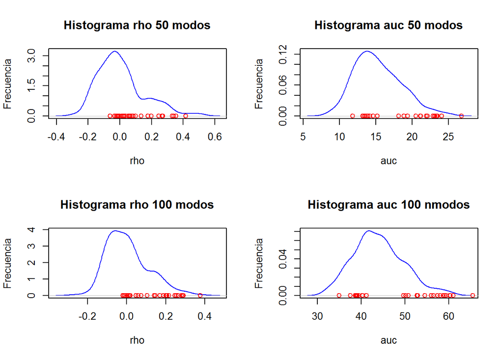

## Pn y Qn

Las distribuciones de *Pn* y *Qn* de los conjuntos son las siguientes:

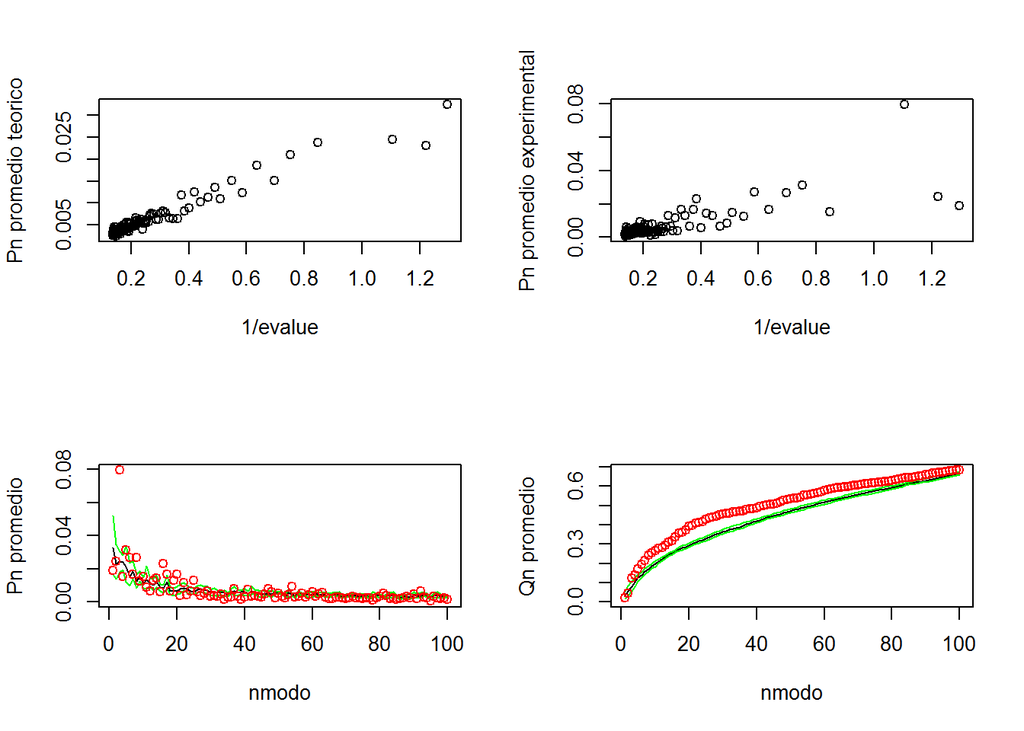

Negro: Teorico Rojo: Experimental Verdes: Cuartiles 0.05 y 0.95 de 10 grupos de 28 mutantes teoricas.